# Your Digest for Tuesday, Sep 12, 2023 11:59 PM

# Aphasia

> [!TIP] Mnemonic  
> *WA***R**ped Banana
> - *WA* - wernicke's aphasia is **R**eceptive (ie Broca's must be expressive), located **P**osteriorly
> - *B*a**N**an**a** - *B*roca's aphasia is **N**on-Fluent (i.e Wernicke's must be Fluent), located **A**nteriorly

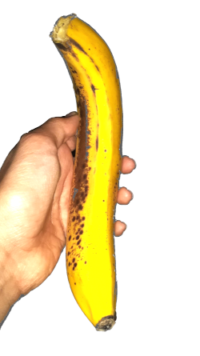

## Receptive aphasia

Also called Wernicke's aphasia, Fluent Aphasia.

> [!TIP] Receptive Aphasia:  
> Language looses meaning - The patient can't understand questions and words come tumbling out.  
> Words and their meaning are dissociated.

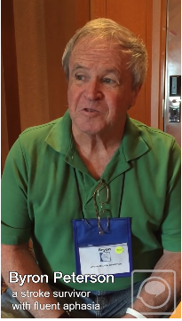

[Source](https://www.youtube.com/watch?v=3oef68YabD0)

## Expressive Aphasia

> [!TIP] Expressive Aphasia:  
> Meaning of language is preserved; The patient can understand questions and knows the 'meaning' of what he want's to say. But the words aren't there. "Tip of the tongue".  
> A 'disorder of expression'

[figure not shown]

> [Source](https://www.youtube.com/watch?v=JWC-cVQmEmY&t=116s)  
> Broca's aphasia, Non-fluent Aphasia  
> **Note:** Mike has paralysis of his right hand -> i.e a left sided lesion

## Broca's and Wernicke's areas

There is a **language loop** in the brain.

> This language loop is found in the left hemisphere in about 90% of right-handed persons and 70% of left-handed persons. [Source](https://thebrain.mcgill.ca/flash/d/d_10/d_10_cr/d_10_cr_lan/d_10_cr_lan.html)

The main components are Broca's area and Wernicke's area connected by the arcuate fasciculus.

- Wernicke's area: *Superior posterior temporal lobe*
- Broca's area: *Posterior inferior frontal gyrus*

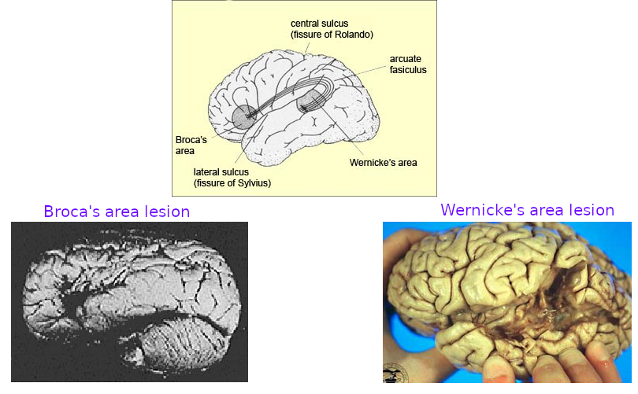

# Alzheimers disease

#2021GM-NOV Q01

## Molecular basis

Transmembrane protein "Amyloid precursor protein" (APP) is broken down by two pathways.

- BACE + gamma-secretase pathway -> produces **Beta amyloid.**
- Alpha secretase + gamma secretase pathway -> produces harmless products.

Mutations in APP or gamma secretase increase the rate of formation of **beta amyloid** which causes Alzheimer's disease.

Beta amyloid accumulation is

- directly toxic to neurons
- Large deposits form **Neuritic plaques** elicit local inflammatory response.
- Causes hyperphosphorylation of intracellular **Tau protein.**
  - Tau protein is a protein which stabilizes microtubules and regulates protein binding to microtubules in healthy cells.
  - Phosphorylation causes Tau protein to redistribute from axons to dendrites and cell bodies where it forms **Neurofibrillary tangles** which cause neuronal dysfunction and cell death.
- So, plaques are extracellular and tangles are intracellular.
- **Neuritic plaques** are collections of dystrophic neurites around a central amyloid core.
  - *There is sparing of the primary motor and sensory cortices until the late stages.*
- Neurofibrillary tangles - intracellular accumulations of phosphorylated Tau protein. They are **not specific to Alzheimer's dementia**.

### Genetic risk factors:

Risk is increased by:

- Down syndrome (APP is on Chromosome 21)
- Point mutations of APP gene.
- E4 allele of apolipoprotein E gene
- Presenilin 1 and 2 - mutations affect gamma secretase function.

### other risk factors

Age, head trauma, vascular factors

## Morphology

Cortical atrophy mainly in frontal, temporal and parietal lobes.  
MRI -> changes visible first in mesial temporal lobe structures including hippocampi (hippocampus).  
Early stage imaging may be normal.

> [!INFO] Limbic System  
> Hippocambus:  
> Essentially the memory centre of our brains. Here, our [episodic memories](https://qbi.uq.edu.au/brain-basics/memory/types-memory) are formed and catalogued to be filed away in [long-term storage](https://qbi.uq.edu.au/brain-basics/memory/where-are-memories-stored) across other parts of the cerebral cortex.  
> Amygdala : "almond like shape"  
> Located right next to the hippocampus, the left and right amygdalae play a central role in our emotional responses, including feelings like pleasure, fear, anxiety and anger. The amygdala also attaches emotional content to our memories, and so plays an important role in determining how robustly those memories are stored. Memories that have strong emotional meaning tend to stick.

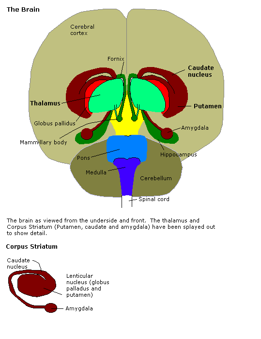

## Pathology of Alzheimers' disease

Most cases are sporadic. Only 5-10% are familial.

> [!INFO] Tau protein

> Tau protein is a protein found in diverse cells like amoebas, insects to humans. It regulated the binding of other proteins to the microtubules. [Source](https://biology.ucdavis.edu/news/understanding-healthy-function-tau-protein-associated-dementia) and helps to stabilize the cytoskeleton of neurons.

Many neurodegenerative diseases are characterised by tangled proteins called Tau filbrils.

## Comparison of types of Dementia

| Alzheimers | Fronto Temporal | Lewy Body | Vascular |
| --- | --- | --- | --- |
| Commonest cause at age > 65 | 🚨Occurs mainly in age < 65 | Similar incidence in > / < 65 groups | Similar incidence in > / < 65 groups |
| Classical dementia picture | Frontal or temporal presentations | 🚨Hallucinations (people or 'presence'), sleep disorders (REM sleep), parkinsonism | apraxic gait, pyramidal signs, urinary incontinence |
|  | Frontal: personality change and 🚨apathy, 🚨episodic memory well preserved! | Memory loss may be absent early on |  |
|  | Temporal: Semantic dementia (i.e like receptive 🚨aphasia) OR progressive non fluent aphasia | Delusions and trasient loss of conciousness |  |
| majority are sporadic | 🚨25% are familial |  |  |
| Tau protein and beta amyloid | - | inclusions of alpha-synuclein |  |
| Mesial temporal lobe structure atrophy | 🚨Asymmetric, frontal and temporal lobe atrophy |  | Widespread small vessel disease seen on MRI |

> [!TIP] Bruce Willis was diagnosed with frontotemporal dementia

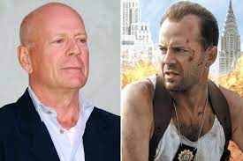

> > After retiring from acting in March 2022 due to a speaking disorder called aphasia, Bruce Willis, 67, has since been diagnosed with **frontotemporal dementia**, his family announced Thursday

# ARDS - acute respiratory distress syndrome

> [!TIP] Summary (read this bit if you're in a hurry.)  
> ARDS is a syndrome of diffuse alveolar damage that occurs because of some systemic or pulmonary insult.  
> Some insult causes increased permeability of either the capillary endothelium or alveolar epithelium leading to diffuse alveolar oedema.  
> This oedema leads to intrapulmonary shunting and volutrauma and atelectrauma.  
> The rest are details

Definition:  
Older definition: an acute condition characterized by **bilateral** *pulmonary infiltrates* and **severe hypoxemia** in the **absence** of evidence for cardiogenic pulmonary edema.

Newer definition:  
A condition causing

- **bilateral** opacities not explained by effusion, consolidation or atelectasis
- Oedema *not fully explained by cardiogenic causes*
- Onset within 1 week of clinical insult
- hypoxaemia of differing severities as defined by P/F radio (at a PEEP of 5cm H2O)
  - 200 - 300 - Mild
  - 100 - 200 - Moderate
  - < 100 - Severe
  - The hypoxaemia is due to significant intrapulmonary **shunting**.

**Pathophysiology:**  
Early exudative phase where alveoli fill with fluid due to increased capillary permeability.

Damage which triggers ARDS can be on either side of the alveolar-capillary membrane:

- to the capillary endothelium (eg sepsis)
- or the alveolar epithelium - (eg after aspiration)

On the alveolar side,  
type II pneumocytes are more resistant to injury but damage to them results in loss of surfactant and alveolar collapse.  
This causes some aveoli to collapse while others becomes overdistended (while on a ventilator).  
ARDS facilitates further lung damage:

- Overdistended alveoli undergo volutrauma.
- The collapsed alveoli undergo cycles of collapse and expansion leading to atelectrauma. (i.e ARDS is an inhomogenous process)
- These types of trauma promote secretion of proinflammatory cytokines.
- Increased airway pressure during ventilation is associated with development of ARDS.

> The use of positive end-expiratory pressure (PEEP) to diminish alveolar collapse and the use of low tidal volumes and limited levels of inspiratory filling pressures appear to be beneficial in diminishing the observed VAL

Causes of ARDS:

[figure not shown]

[output not shown]

> [!INFO] 'Positive features' of Ulcerative colitis not seen in Crohn's disease
> - Toxic megacolon can occur.
> - Marked pseudopolyps
> - ? More malignant potential
> - Rectal involvement is **always present**
> - primary sclerosing cholangitis (seen *mostly* with UC)

Ileal resection can cause bile acid malabsorption -> diarrhoea.****

# Primary sclerosing cholangitis

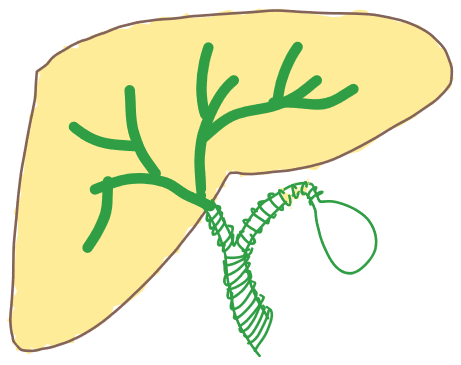

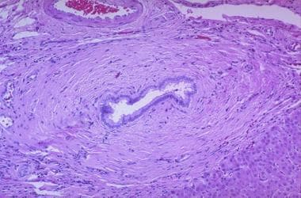

Progressive and chronic liver disease caused by autoimmune mediated fibrosis of intra and extrahepatic bile ducts.  
Often complicated by **cholangiocarcinoma**.  
Treament is not curative; it's aimed at minimizing symptoms and managing complications.  
**Liver transplantation** is the only treatment than can alter progression.  
Affects young to middle aged **males**.  
PSC without IBD is more likely to occur in women.  
PSC is seen predominantly in non smokers.  
Ix: AST, ALT, GGT all elevated. Fluctuating conjugated hyperbilirubinaemia.

**hypergammaglobulinaemia** is present.  
Best imaging modality: MRCP